# Microsoft SQL Server and R Services

Steph Locke (@SteffLocke)

2017-04-20

# Steph Locke

- Locke Data
- Presenter on Data Science, BI, and DataOps
- Microsoft Data Platform MVP
- User group leader: [MSFT Stack](http://www.meetup.com/MSFT%20Stack) & [CaRdiff](http://www.meetup.com/Cardiff-R-User-Group/)
- Conference organiser: [satRdays](http://planning.satrdays.org) & [Battle of the Beards](http://battleofthebeards.info)

github.com/StephLocke | itsalocke.com | [T: SteffLocke](https://twitter.com/stefflocke)

# SQL Server

# Overview

- RDBMS
- Use on physical or virtual machines

# Key things to manage

- Data
- Code
- Permissions
- Licences

# Next steps

- [Books Online](https://msdn.microsoft.com/en-us/library/ms130214.aspx)
- [SQL Server Central](http://www.sqlservercentral.com/)

# R

# Overview

> R is an integrated suite of software facilities for data manipulation, calculation and graphical display
- Open source
- In-memory & single-core (by default)
- Multi-platform
- Extensible environment
- Delivered by the [R Foundation](https://www.r-project.org/foundation/), supported by the [R Consortium](https://www.r-consortium.org/), grown by R developers
- [r-project.org](http://www.r-project.org/)

# What’s it look like?

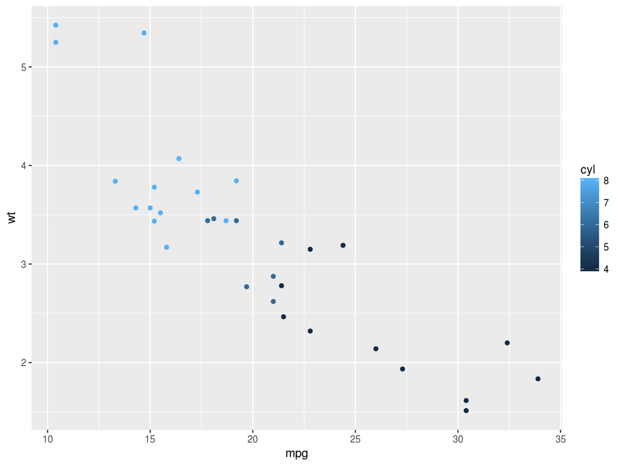

```r
ggplot2::qplot(mpg, wt, data = mtcars, colour = cyl)
```

# Versions

- [“Standard” R](https://r-project.org)
- [Microsoft R Open](https://mran.revolutionanalytics.com/download/)
- [Microsoft R Server](https://msdn.microsoft.com/en-us/library/mt674876.aspx)
- [TERR](https://docs.tibco.com/products/tibco-enterprise-runtime-for-r)
- [Oracle R](http://www.oracle.com/technetwork/database/database-technologies/r/r-distribution/overview/index.html)

# Key things to manage

- Packages
- RAM
- Code

# Next steps

- [Learn R](https://datacamp.com)
- [Check out some of my other intros to R](http://stephlocke.info/Rtraining)

# SQL Server + R Services

# Overview

- Call R through SQL Server

# What’s it look like?

```
EXECUTE   sp_execute_external_script
                @language = N'R'
              , @script = N'OutputDataSet <- df<-as.data.frame(installed.packages()[,1])'
              , @input_data_1 = N'SELECT 1 as Col'
 WITH RESULT SETS ((col varchar(50) not null))
```

# 2016 Editions

- Express - R Open or base R
- Standard - R Open or base R
- Enterprise - R Server

[SQL Server feature comparison](https://www.microsoft.com/en-ie/sql-server/sql-server-editions)

# Key things to manage

- RAM & CPU
- Licenses vs Server resources
- Permissions
- Code

# Next steps

- [Tomaz Kastrun blog](https://tomaztsql.wordpress.com/)
- [BOL](https://msdn.microsoft.com/en-us/library/mt604845.aspx)

# Deploying SQL Server & R Services

# Azure is your friend

- Automatable
- Disposable
- Scalable

# ARM templates

- JSON specification of resources
- Paramaterised for reuse
- Downloadable
- Deploy in many different languages

# PowerShell

- Azure modules
- Use ARM templates
- Used in Azure Automation

# Demo

[Github](https://github.com/stephlocke/SQLServerVM-tidyverse)

# Next steps

- [Authoring ARM templates](https://azure.microsoft.com/en-gb/documentation/articles/resource-group-authoring-templates/)
- [PowerShell basics](https://msdn.microsoft.com/en-us/powershell/scripting/getting-started/fundamental/windows-powershell-basics)
- [Azure overview](https://azure.microsoft.com/en-gb/overview/what-is-azure/)

# Other Microsoft & R things

# Azure ML

- GUI data science
- R & Python
- Notebooks
- Code deployment potential
- Easy webservices

# R in PowerBI

- Interactive reports
- R data source
- R graphics

# Wrapup

# Wrapup

- Thank you
- Check out the Next Steps
- Get in touch! [T: SteffLocke](https://twitter.com/stefflocke)